# Introducció a l’estadística amb R

Sessió 3 · Estadística bivariada: relacions entre dues variables

Joel Ardiaca

Centre d’Estudis d’Opinió

2 de novembre del 2026

# Benvinguda

## Què farem avui?

| Hora | Què farem |
| --- | --- |
| 9.30 | **Teoria**: relacions entre dues variables |
| 10.20 | **Repàs de R**: tot el que ja sabem fer… i tres coses noves: `count()` amb dues variables, `arrange()` i `group_by()` |
| 11.00 | *Pausa* |
| 11.30 | **Pràctica**: estadística bivariada amb R, cadascú al seu ritme |
| 13.20 | Tancament |

Fins a la pausa, **no cal obrir RStudio**: mireu i pregunteu. Després de la pausa, tot el temps és vostre.

# Relacions entre dues variables

## Variable dependent i independent

### Variable independent (VI)

- La que **explica** o es considera la causa
- També: explicativa, predictor, factor

### Variable dependent (VD)

- La que volem **estudiar o predir**
- També: variable resposta, resultat

**Exemples**

- **Ingressos** (VD) segons **nivell d’estudis** (VI)
- **Nota de matemàtiques** (VD) segons **titularitat del centre** (VI)

## Quina tècnica fem servir?

Depèn del **tipus** de les dues variables:

|  | **VI categòrica** | **VI numèrica** |
| --- | --- | --- |
| **VD categòrica** | Taules de contingència, $\chi^2$ **Avui** | (Regressió logística) |
| **VD numèrica** | Comparació de mitjanes: t-test, ANOVA **Avui** | Correlació i regressió **Sessió 4** |

# Dues variables categòriques

## La taula de contingència

- Creua **dues variables categòriques**: cada cel·la diu quants casos hi ha de cada **combinació**
- Exemple: enquesta del CEO a joves de menys de 20 anys. **VI**: sexe; **VD**: fa servir TikTok?

| Fa servir TikTok? | Home | Dona | Total |
| --- | --- | --- | --- |
| Sí | 138 | 136 | 274 |
| No | 98 | 60 | 158 |
| Total | 236 | 196 | 432 |

Ara no ens fixem en el codi: el veurem al repàs de R.

## Hi ha associació? Casos extrems

**Cap associació**

|  | Home | Dona |
| --- | --- | --- |
| A favor | 150 | 150 |
| En contra | 150 | 150 |

El sexe **no diu res** de l’opinió

**Associació parcial**

|  | Home | Dona |
| --- | --- | --- |
| A favor | 180 | 150 |
| En contra | 120 | 150 |

Els homes, **una mica** més a favor

**Associació perfecta**

|  | Home | Dona |
| --- | --- | --- |
| A favor | 300 | 0 |
| En contra | 0 | 300 |

Sabent el sexe, **sabem** l’opinió

Hi ha **associació** quan la distribució de la VD **canvia** d’un grup de la VI a un altre.

## Per comparar: percentatges dins de cada grup

| Fa servir TikTok? (%) | Home | Dona |
| --- | --- | --- |
| Sí | 58,5 | 69,4 |
| No | 41,5 | 30,6 |

Un **58,5 %** dels nois i un **69,4 %** de les noies fan servir TikTok: hi ha **11 punts** de diferència. Sembla que hi ha associació… però és una **mostra**. Podria ser fruit de l’**atzar**?

Regla: els percentatges de la **VD** (TikTok), calculats **dins de cada grup de la VI** (sexe). Cada columna suma 100.

## Què esperaríem si no hi hagués associació?

Si el sexe no tingués res a veure amb TikTok, nois i noies l’usarien **igual**: el 63,4 % del total.

**Observades** ($O$): el que hem trobat

| TikTok? | Home | Dona |
| --- | --- | --- |
| Sí | 138 | 136 |
| No | 98 | 60 |

**Esperades** ($E$): si no hi hagués associació

| TikTok? | Home | Dona |
| --- | --- | --- |
| Sí | 149,7 | 124,3 |
| No | 86,3 | 71,7 |

Esperaríem 149,7 nois usuaris i n’hem trobat 138: **menys** del que tocaria. I 124,3 noies usuàries, i n’hem trobat 136: **més**. Com més s’allunyen $O$ i $E$, més evidència d’associació.

## El test $\chi^2$ (khi-quadrat)

- $H_0$: **no hi ha associació**
- $H_1$: **hi ha associació**

$$\chi^2 = \sum \frac{(O - E)^2}{E}$$

- El $\chi^2$ diu **com de lluny** és la taula observada ($O$) de l’esperada ($E$)
- $\chi^2 = 0$: no hi ha cap diferència. Com més **gran**, més lluny de la independència

**p-valor**: la probabilitat de trobar una diferència com la nostra **només per atzar**, si no hi hagués associació. Si **p < 0,05**, rebutgem $H_0$.

## El test $\chi^2$ amb R

```r
chisq.test(tiktok$sexe, tiktok$usa_tiktok)
```

```
    Pearson's Chi-squared test with Yates' continuity correction

data:  tiktok$sexe and tiktok$usa_tiktok
X-squared = 5.0369, df = 1, p-value = 0.02481
```

**p = 0,025 < 0,05** → rebutgem $H_0$: hi ha **associació significativa** entre el sexe i l’ús de TikTok. La diferència d’11 punts difícilment és fruit de l’atzar.

Necessita freqüències esperades **> 5** a totes les cel·les. Si no, R avisa («*Chi-squared approximation may be incorrect*») i cal fer servir `fisher.test()`. 📖 **Per aprofundir**: la distribució khi-quadrat i significativa no vol dir forta: la V de Cramér.

# Una numèrica i una categòrica

## Comparar mitjanes entre grups

Quan una variable **numèrica** (ingressos, nota…) pot variar segons una **categòrica** (sexe, estudis…):

1. Calculem la **mitjana** (i la dispersió) de cada grup
2. Ho mirem amb un **boxplot** per grup
3. Contrastem si la diferència és **significativa**:
   - **2 grups** → **t-test**
   - **3 o més grups** → **ANOVA**

Als exemples, dades **simulades** d’ingressos mensuals.

## Dos grups: el t-test

Exemple: ingressos mensuals (simulats) de 150 homes i 150 dones.

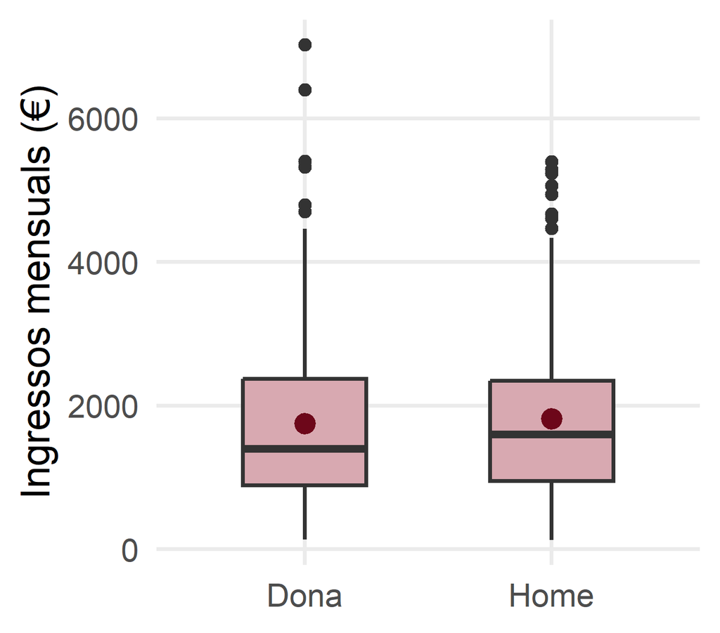

El punt és la **mitjana** de cada grup.

| Sexe | n | Mitjana (€) | Desv. típica (€) |
| --- | --- | --- | --- |
| Dona | 150 | 1.753 | 1.260 |
| Home | 150 | 1.819 | 1.198 |

Els homes cobren, de mitjana, **66 €** més. Però és una **mostra**: podria ser fruit de l’**atzar**?

- $H_0$: a la població, les dues mitjanes són **iguals**
- $H_1$: les mitjanes són **diferents**

**66 €, és molt o poc?** Depèn de com variïn els ingressos **dins** de cada grup, i de quantes persones tinguem.

## La idea: la diferència, comparada amb l’error

Com a la sessió 2: cada mostra dona una mitjana diferent. L’**error estàndard** diu quant pot variar, per atzar, la diferència entre les dues mitjanes. El t-test compara la diferència amb aquest error:

$$t = \frac{\text{diferència de mitjanes}}{\text{error estàndard de la diferència}} = \frac{\bar{x}_1 - \bar{x}_2}{\sqrt{\frac{s_1^2}{n_1} + \frac{s_2^2}{n_2}}}$$

El $t$ és **gran** (en valor absolut) quan:

- la **diferència** entre mitjanes és gran
- els grups són **poc dispersos** ($s$ petita)
- els grups són **grans** ($n$ gran)

**Regla del 95 %** (sessió 2): si $|t| > 1{,}96$ (≈ 2), la diferència és més gran del que sol donar l’atzar → **p < 0,05**.

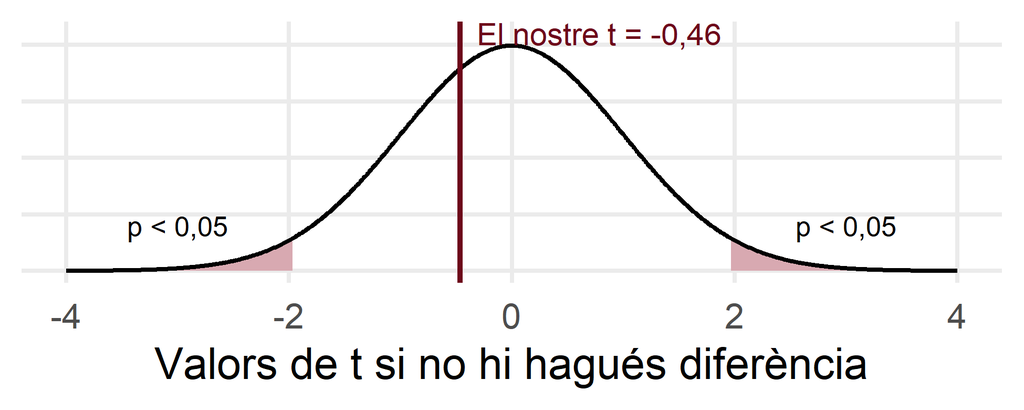

$t = -66 / 142 = -0{,}46$: la diferència no arriba a **mig** error estàndard. És molt habitual per atzar.

## El t-test amb R

La fórmula `numerica ~ grup` es llegeix «*ingressos **segons** sexe*»:

```r
t.test(ingressos ~ sexe, data = ingressos_sexe)
```

```
    Welch Two Sample t-test

data:  ingressos by sexe
t = -0.46338, df = 297.24, p-value = 0.6434
alternative hypothesis: true difference in means between group Dona and group Home is not equal to 0
95 percent confidence interval:
 -345.1945  213.6169
sample estimates:
mean in group Dona mean in group Home
          1753.475           1819.264
```

**Com es llegeix?**

- **`t`**: l’estadístic (el signe només diu quin grup té la mitjana més alta)
- **`p-value`**: 0,64 > 0,05 → **no** rebutgem $H_0$
- **`95 percent confidence interval`**: l’interval de la **diferència** de mitjanes. Inclou el **0** → coherent amb el p-valor
- **`sample estimates`**: la mitjana de cada grup

Els homes cobren 66 € més a la mostra, però **no podem afirmar** que la diferència existeixi a la població.

📖 **Per aprofundir**: què fa per dins `t.test()`? (sessió 2) i proves de normalitat

## Tres o més grups: per què no fem t-tests?

Amb 3 grups (Bàsic, Mitjà, Superior) hi ha **3 parelles** per comparar. Amb 5 grups, **10 parelles**.

- Cada t-test té un **5 %** de probabilitat d’equivocar-se (trobar una diferència que no existeix)
- Si en fem molts, la probabilitat d’equivocar-nos **en algun** es dispara

L’**ANOVA** (anàlisi de la variància) respon d’un sol cop: **hi ha alguna diferència** entre les mitjanes dels grups?

- $H_0$: **totes** les mitjanes són iguals
- $H_1$: **almenys una** mitjana és diferent

## La idea de l’ANOVA: variació entre i dins dels grups

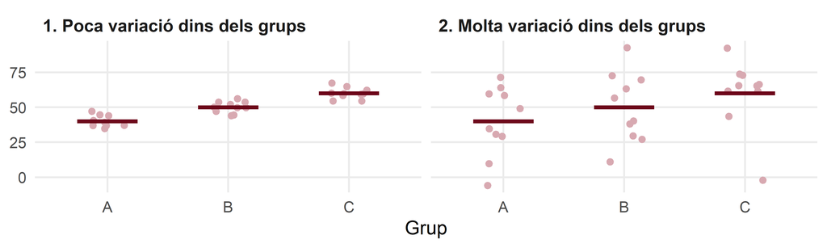

En tots dos casos les mitjanes (línies) són **les mateixes**: 40, 50 i 60. Però:

- **Esquerra**: els grups estan ben **separats** → les diferències entre mitjanes **són clares**
- **Dreta**: els grups es **barregen** → les mateixes diferències podrien ser **atzar**

## L’estadístic F

L’ANOVA compara les dues fonts de variació:

$$F = \frac{\text{variació } \textbf{entre} \text{ grups (com d'allunyades estan les mitjanes)}}{\text{variació } \textbf{dins} \text{ dels grups (com d'escampats estan els casos)}}$$

**F gran** → les mitjanes estan lluny en comparació amb la variació interna → **p petit** → hi ha diferències

A l’exemple de l’esquerra: F = 62,5

**F petit** (a prop d’1) → les diferències entre mitjanes són com la variació normal → **p gran** → no podem dir que n’hi hagi

A l’exemple de la dreta: F = 1,6

Supòsits: observacions **independents**, variable **normal** dins de cada grup (o grups grans) i variàncies **semblants**. 📖 **Per aprofundir**: la distribució F i com es calcula l’ANOVA.

## L’ANOVA amb R

Ingressos segons el nivell d’estudis:

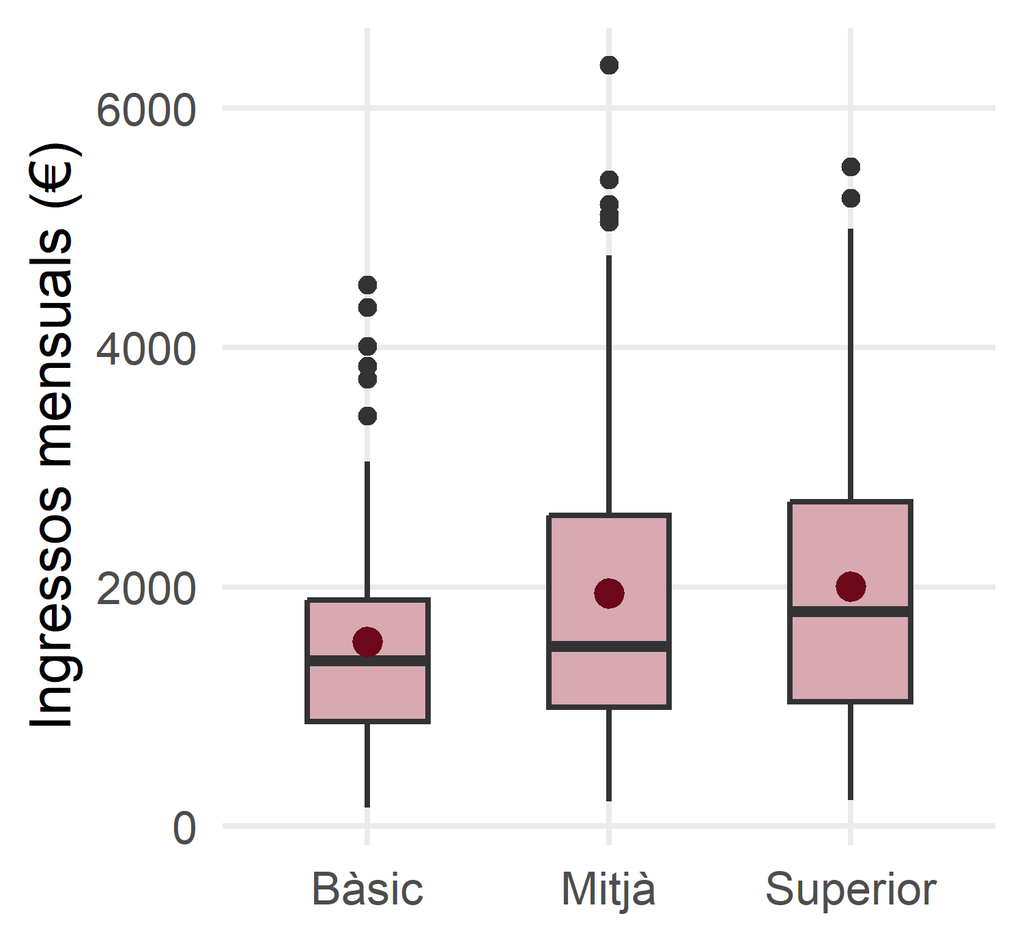

```r
model <- aov(ingressos ~ estudis,
             data = ingressos_estudis)
summary(model)
```

```
             Df    Sum Sq Mean Sq F value  Pr(>F)
estudis       2  12892062 6446031   4.772 0.00913 **
Residuals   297 401206916 1350865
---
Signif. codes:  0 '***' 0.001 '**' 0.01 '*' 0.05 '.' 0.1 ' ' 1
```

- `F value`: l’estadístic F (4,77)
- `Pr(>F)`: el **p-valor** (0,009)

**p < 0,05** → rebutgem $H_0$: **no** tots els nivells d’estudis tenen els mateixos ingressos mitjans.

## Entre quins grups? La prova de Tukey

L’ANOVA diu que **hi ha alguna diferència**, però no **on**. La prova *post hoc* de Tukey compara **totes les parelles**, corregint el problema de fer moltes comparacions:

```r
TukeyHSD(model)
```

```
  Tukey multiple comparisons of means
    95% family-wise confidence level

Fit: aov(formula = ingressos ~ estudis, data = ingressos_estudis)

$estudis
                    diff        lwr      upr     p adj
Mitjà-Bàsic    407.37716   20.20095 794.5534 0.0365334
Superior-Bàsic 466.20301   79.02680 853.3792 0.0134874
Superior-Mitjà  58.82585 -328.35036 446.0021 0.9318529
```

Mireu la columna `p adj`: **Bàsic** és diferent de **Mitjà** i de **Superior** (p < 0,05); entre **Mitjà** i **Superior**, la diferència **no** és significativa.

## Resum: quina prova per a què?

| Variables | Descriure | Contrastar ($H_0$: no hi ha relació) |
| --- | --- | --- |
| **2 categòriques** | % de la VD dins de cada grup de la VI | $\chi^2$: `chisq.test()` |
| **Numèrica** segons **categòrica (2 grups)** | Mitjana per grup, boxplot | t-test: `t.test()` |
| **Numèrica** segons **categòrica (3+ grups)** | Mitjana per grup, boxplot | ANOVA: `aov()` + `TukeyHSD()` |

Sempre en el mateix ordre: primer **descriure** (quina diferència hi ha? és gran?), després **contrastar** (p < 0,05 → la relació és **significativa**).

# Repàs de R: què sabem fer?

## Sempre comencem igual

```r
# Carreguem el tidyverse
```

```r
library(tidyverse)
```

```r
# Importem les dades (CSV amb ; i coma decimal)
```

```r
competencies <- read_csv2("dades/competencies.csv")
```

```r
# Mirem què hi ha
```

```r
glimpse(competencies)
```

```
Rows: 480
Columns: 9
$ id           <dbl> 3039061722, 4159117078, 8139769361, 4512109196,…
$ genere       <chr> "Dona", "Home", "Dona", "Dona", "Home", "Dona",…
$ titularitat  <chr> "Privat", "Públic", "Privat", "Públic", "Públic…
$ habitat      <fct> De 10001 a 100000, Més de 100000, Més de 100000…
$ nota_cat     <dbl> 86.8, 33.9, 78.5, 74.8, 89.9, 88.5, 55.5, 85.2,…
$ nota_mat     <dbl> 86.9, 59.2, 81.6, 77.3, 97.9, 83.7, 28.0, 77.3,…
$ nota_ang     <dbl> 88.67, 82.58, 95.58, 59.00, 100.00, 81.92, 82.8…
$ nota_mitjana <dbl> 87.45667, 58.56000, 85.22667, 70.36667, 95.9333…
$ nivell_mat   <fct> Alt, Mitjà, Alt, Alt, Alt, Alt, Baix, Alt, Mitj…
```

## Els verbs del tidyverse

Un **verb** agafa una taula de dades, hi fa **una cosa** i en torna una altra taula. Ja en coneixem sis:

| Verb | Què fa | Treballa amb… |
| --- | --- | --- |
| `filter()` | **Tria files** que compleixen una condició | Files |
| `select()` | **Tria columnes** | Columnes |
| `rename()` | **Canvia el nom** de columnes | Columnes |
| `mutate()` | **Crea o modifica** columnes | Columnes |
| `count()` | **Compta** quantes files hi ha de cada categoria | Resum |
| `summarise()` | **Resumeix** moltes files en una (mitjana, mediana…) | Resum |

Els enllacem amb el pipe **`|>`**, que es llegeix «**i després**».

## Triar i transformar, pas a pas

```r
# Agafa les dades i després...
```

```r
competencies |>
```

```r
  # ...queda't amb els centres públics
```

```r
  filter(titularitat == "Públic") |>
```

```r
  # ...tria tres columnes
```

```r
  select(genere, nota_cat, nota_mat) |>
```

```r
  # ...canvia el nom de genere per sexe
```

```r
  rename(sexe = genere) |>
```

```r
  # ...i crea la nota de mates sobre 10
```

```r
  mutate(nota_mat_10 = nota_mat / 10)
```

```
# A tibble: 317 × 4
   sexe  nota_cat nota_mat nota_mat_10
   <chr>    <dbl>    <dbl>       <dbl>
 1 Home      33.9     59.2        5.92
 2 Dona      74.8     77.3        7.73
 3 Home      89.9     97.9        9.79
 4 Dona      88.5     83.7        8.37
 5 Home      55.5     28          2.8
 6 Dona      85.2     77.3        7.73
 7 Dona      80.5     73.3        7.33
 8 Home      42.7     52.9        5.29
 9 Home      69.8     83.7        8.37
10 Dona      95.8     92.5        9.25
# ℹ 307 more rows
```

## Resumir: `count()` i `summarise()`

```r
# Quants alumnes hi ha de cada nivell
# de matemàtiques?
```

```r
competencies |>
  count(nivell_mat)
```

```
# A tibble: 3 × 2
  nivell_mat     n
  <fct>      <int>
1 Baix          59
2 Mitjà        173
3 Alt          248
```

```r
# Quina és la nota mitjana i la
# mediana de matemàtiques?
```

```r
competencies |>
  summarise(mitjana = mean(nota_mat),
            mediana = median(nota_mat))
```

```
# A tibble: 1 × 2
  mitjana mediana
    <dbl>   <dbl>
1    73.6    76.2
```

`count()` i `summarise()` **redueixen** la taula: de 480 files (alumnes) passem a una fila per categoria o a una sola fila.

## Guardar o només mirar?

Amb `<-` **guardem** el resultat en un objecte. Sense `<-`, R el **mostra** per pantalla i se n’oblida.

```r
# 1. Un canvi que volem CONSERVAR a les dades: sobreescrivim el mateix objecte
```

```r
competencies <- competencies |>
  rename(nota_global = nota_mitjana)
```

```r
# 2. Un resultat NOU que volem fer servir després: el guardem amb un altre nom
```

```r
taula_nivells <- competencies |>
  count(nivell_mat)
```

```r
# 3. Només volem VEURE la resposta (una mitjana, una taula...): sense <-
```

```r
competencies |>
  summarise(mitjana = mean(nota_mat))
```

Els objectes guardats apareixen al panell **Environment**. Compte: `competencies <- ...` **substitueix** les dades d’abans. Si us equivoqueu, torneu a executar l’script des del principi.

## I les funcions «auxiliars»

No són verbs: treballen amb **una columna** i van **a dins** d’un verb.

| Funció | Per a què | A dins de… |
| --- | --- | --- |
| `case_when()` | **Recodificar**: `case_when(x == "D" ~ "Dona", ...)` | `mutate()` |
| `factor()` | **Ordenar** les categories | `mutate()` |
| `is.na()` | Detectar **valors perduts** (`NA`) | `filter()` |
| `mean()`, `median()`, `sd()`, `quantile()` | Mitjana, mediana, desviació típica, quartils | `summarise()` |
| `n()` | **Comptar** files | `summarise()` |

## Verbs i auxiliars junts

```r
# Agafa les dades i després...
competencies |>
```

```r
  # ...crea una columna: aprova mates?
```

```r
  mutate(aprova_mat = case_when(nota_mat >= 50 ~ "Sí",
                                nota_mat <  50 ~ "No")) |>
```

```r
  # ...i compta quants n'hi ha de cada
  count(aprova_mat)
```

```
# A tibble: 2 × 2
  aprova_mat     n
  <chr>      <int>
1 No            59
2 Sí           421
```

El **verb** (`mutate()`) diu **què** fem amb la taula: crear una columna. L’**auxiliar** (`case_when()`) diu **com** es calcula aquesta columna.

# Tres novetats per a la bivariada

## Novetat 1: `count()` amb dues variables

```r
# Abans: una variable
competencies |>
  count(nivell_mat)
```

```
# A tibble: 3 × 2
  nivell_mat     n
  <fct>      <int>
1 Baix          59
2 Mitjà        173
3 Alt          248
```

```r
# Ara: dues variables
competencies |>
  count(genere, nivell_mat)
```

```
# A tibble: 6 × 3
  genere nivell_mat     n
  <chr>  <fct>      <int>
1 Dona   Baix          33
2 Dona   Mitjà        102
3 Dona   Alt          112
4 Home   Baix          26
5 Home   Mitjà         71
6 Home   Alt          136
```

Una fila per a cada **combinació** de gènere i nivell. És la **taula de contingència**, posada «en vertical»: cada fila és una cel·la.

## Novetat 2: `arrange()`, ordenar les files

```r
# De menys a més
competencies |>
  count(genere, nivell_mat) |>
  arrange(n)
```

```
# A tibble: 6 × 3
  genere nivell_mat     n
  <chr>  <fct>      <int>
1 Home   Baix          26
2 Dona   Baix          33
3 Home   Mitjà         71
4 Dona   Mitjà        102
5 Dona   Alt          112
6 Home   Alt          136
```

```r
# De més a menys: desc()
competencies |>
  count(genere, nivell_mat) |>
  arrange(desc(n))
```

```
# A tibble: 6 × 3
  genere nivell_mat     n
  <chr>  <fct>      <int>
1 Home   Alt          136
2 Dona   Alt          112
3 Dona   Mitjà        102
4 Home   Mitjà         71
5 Dona   Baix          33
6 Home   Baix          26
```

`arrange()` no canvia res de les dades: només l’**ordre** de les files. `desc()` (de *descending*) és una auxiliar.

## Novetat 3: `group_by()`, la idea

`group_by()` **no canvia** les dades: les **separa en grups**. El verb que ve **després** es fa **per a cada grup** per separat.

```r
competencies |>
  group_by(genere)
```

```
# A tibble: 480 × 9
# Groups:   genere [2]
          id genere titularitat habitat     nota_cat nota_mat nota_ang
       <dbl> <chr>  <chr>       <fct>          <dbl>    <dbl>    <dbl>
1 3039061722 Dona   Privat      De 10001 a…     86.8     86.9     88.7
2 4159117078 Home   Públic      Més de 100…     33.9     59.2     82.6
3 8139769361 Dona   Privat      Més de 100…     78.5     81.6     95.6
# ℹ 477 more rows
# ℹ 2 more variables: nota_mitjana <dbl>, nivell_mat <fct>
```

Les dades són les mateixes, però a dalt hi diu **`# Groups: genere [2]`**: R recorda que hi ha 2 grups (dones i homes).

## `group_by()` + `count()`: percentatges dins de cada grup

```r
# Sense group_by(): % sobre el TOTAL
competencies |>
  count(genere, nivell_mat) |>
  mutate(pct = n / sum(n) * 100)
```

```
# A tibble: 6 × 4
  genere nivell_mat     n   pct
  <chr>  <fct>      <int> <dbl>
1 Dona   Baix          33  6.88
2 Dona   Mitjà        102 21.2
3 Dona   Alt          112 23.3
4 Home   Baix          26  5.42
5 Home   Mitjà         71 14.8
6 Home   Alt          136 28.3
```

`sum(n)` = 480 alumnes. Els 6 % sumen 100.

```r
# Amb group_by(): % dins de cada GÈNERE
competencies |>
  count(genere, nivell_mat) |>
  group_by(genere) |>
  mutate(pct = n / sum(n) * 100)
```

```
# A tibble: 6 × 4
# Groups:   genere [2]
  genere nivell_mat     n   pct
  <chr>  <fct>      <int> <dbl>
1 Dona   Baix          33  13.4
2 Dona   Mitjà        102  41.3
3 Dona   Alt          112  45.3
4 Home   Baix          26  11.2
5 Home   Mitjà         71  30.5
6 Home   Alt          136  58.4
```

`sum(n)` = 247 dones i 233 homes. Sumen 100 **dins de cada gènere**: el 58,4 % dels nois té nivell alt, davant del 45,3 % de les noies.

## `ungroup()`: treure els grups

Després de `group_by()`, el resultat **queda agrupat**: tot el que vingui després es farà per grups. Quan ja no ho volem, **`ungroup()`**:

```r
competencies |>
  count(genere, nivell_mat) |>
  group_by(genere) |>
  mutate(pct_genere = n / sum(n) * 100) |>
```

```r
  # ...i ara traiem els grups
  ungroup() |>
```

```r
  # ...i el % sobre el total d'alumnes
  mutate(pct_total = n / sum(n) * 100)
```

```
# A tibble: 6 × 5
  genere nivell_mat     n pct_genere pct_total
  <chr>  <fct>      <int>      <dbl>     <dbl>
1 Dona   Baix          33       13.4      6.88
2 Dona   Mitjà        102       41.3     21.2
3 Dona   Alt          112       45.3     23.3
4 Home   Baix          26       11.2      5.42
5 Home   Mitjà         71       30.5     14.8
6 Home   Alt          136       58.4     28.3
```

Bon costum: acabar amb **`ungroup()`** quan ja no necessitem els grups. Ja no hi diu `# Groups`.

## `group_by()` + `summarise()`: un resum per grup

```r
# Sense group_by(): una sola fila
competencies |>
  summarise(n = n(),
            mitjana_mat = mean(nota_mat))
```

```
# A tibble: 1 × 2
      n mitjana_mat
  <int>       <dbl>
1   480        73.6
```

```r
# Amb group_by(): una fila PER GRUP
competencies |>
  group_by(genere) |>
  summarise(n = n(),
            mitjana_mat = mean(nota_mat))
```

```
# A tibble: 2 × 3
  genere     n mitjana_mat
  <chr>  <int>       <dbl>
1 Dona     247        71.5
2 Home     233        75.8
```

`group_by(genere) |> summarise(...)` es llegeix: «**per a cada gènere**, calcula…».

## Diverses variables alhora

```r
# Per a cada gènere, quants alumnes hi ha i quina nota mitjana treuen a cada assignatura?
competencies |>
  group_by(genere) |>
  summarise(n           = n(),
            mitjana_cat = mean(nota_cat, na.rm = TRUE),
            mitjana_mat = mean(nota_mat),
            mitjana_ang = mean(nota_ang, na.rm = TRUE))
```

```
# A tibble: 2 × 5
  genere     n mitjana_cat mitjana_mat mitjana_ang
  <chr>  <int>       <dbl>       <dbl>       <dbl>
1 Dona     247        77.3        71.5        80.8
2 Home     233        71.5        75.8        76.1
```

Les noies treuen més nota de **català** i d’**anglès**; els nois, de **matemàtiques**. (Compte amb els `NA`: `na.rm = TRUE`.)

## Dos grups alhora, ordenat i desagrupat

```r
# Per a cada gènere I hàbitat...
competencies |>
  group_by(genere, habitat) |>
```

```r
  # ...nombre d'alumnes i nota de català
  summarise(n = n(),
            mitjana_cat = mean(nota_cat, na.rm = TRUE)) |>
```

```r
  # ...traiem els grups
  ungroup() |>
```

```r
  # ...i ordenem de més a menys nota
  arrange(desc(mitjana_cat))
```

```
# A tibble: 6 × 4
  genere habitat               n mitjana_cat
  <chr>  <fct>             <int>       <dbl>
1 Dona   Fins a 10000         52        79.9
2 Dona   Més de 100000        83        77.4
3 Dona   De 10001 a 100000   112        76.0
4 Home   Fins a 10000         49        74.9
5 Home   De 10001 a 100000   100        71.4
6 Home   Més de 100000        84        69.7
```

Si R mostra un missatge sobre com queda agrupat el resultat del `summarise()`, no és cap error: amb `ungroup()` ens n’oblidem.

## Xuleta: bivariada amb R

| Vull… | Codi |
| --- | --- |
| Taula de contingència | `count(vi, vd)` |
| % de la VD dins de cada grup de la VI | `count(vi, vd) \|> group_by(vi) \|> mutate(pct = n / sum(n) * 100) \|> ungroup()` |
| Resum d’una numèrica per grup | `group_by(grup) \|> summarise(n = n(), mitjana = mean(x))` |
| Per a dues variables de grup | `group_by(grup1, grup2) \|> summarise(...) \|> ungroup()` |
| Ordenar les files | `arrange(x)` o, de més a menys, `arrange(desc(x))` |

**Opcional**, per saber si les diferències són significatives: `chisq.test(dades$vi, dades$vd)`, `t.test(x ~ grup, data = dades)` i `summary(aov(x ~ grup, data = dades))`.

# Pausa ☕

# Pràctica: bivariada amb R

## Pas a pas: obrir els materials de la sessió 3

1. Descarregueu el **zip** de la sessió 3 de la web del curs
2. **Descomprimiu-lo**: botó dret → *Extreu-ho tot*. No treballeu des de dins del zip!
3. Entreu a la carpeta descomprimida i feu **doble clic** a `sessio_3.Rproj`
4. Comproveu que a dalt a la dreta de RStudio hi diu **`sessio_3`**
5. Al panell *Files* (a baix a la dreta), obriu la carpeta `codi/` i l’script `exercici_sessio_3.R`
6. Executeu el **pas 1**, que ja està fet: ha de sortir una taula de 480 files

Les dades (`dades/competencies.csv`) són les **mateixes dades netes** de la sessió 2: tothom comença des del mateix punt. A `codi/01_bivariada.R` hi ha tot el codi de les slides.

## Pràctica: cadascú al seu ritme

Tot és a la plantilla `codi/exercici_sessio_3.R`:

|  | Què farem | Amb… |
| --- | --- | --- |
| **Pas 1** | Importar les dades (**ja fet**: només cal executar-lo) | `read_csv2()` |
| **Part A** · passos 2 a 4 | El nivell de matemàtiques segons la **titularitat** i l’**hàbitat** | `count()` + `group_by()` |
| **Part B** · passos 5 a 7 | Les notes segons la **titularitat**, l’**hàbitat** i el **gènere** | `group_by()` + `summarise()` |
| *Opcional 1* | Les diferències, **són significatives**? | `chisq.test()`, `t.test()` |
| *Opcional 2* | **Repte**: l’esperança de vida per continent | Tot el que sabeu |
| *Opcional 3* | Tutorial: gràfics bivariats amb `ggplot2` | `ggplot()` |

L’important avui: **`count()`, `group_by()` i `summarise()`**. Si arribeu a la part opcional, perfecte; si no, també.

## Part A: dues variables categòriques

El nivell de matemàtiques (`nivell_mat`, **VD**), és diferent segons la titularitat del centre (`titularitat`, **VI**)?

**Pas 2. Taula de contingència** amb `count()` i dues variables. Quants alumnes de centres públics tenen nivell alt?

**Pas 3. Percentatges dins de cada titularitat**: afegiu-hi `group_by(titularitat)`, `mutate(percentatge = n / sum(n) * 100)` i `ungroup()`. On hi ha més alumnes amb nivell alt?

**Pas 4. Ara sols**: el mateix (passos 2 i 3) amb **`habitat`** en lloc de `titularitat`. El percentatge de nivell alt, canvia segons la mida del municipi?

Escriviu les respostes **en paraules**, amb comentaris (`#`). La xuleta i `codi/01_bivariada.R` us fan de guia.

## Part B: una numèrica i una categòrica

**Pas 5. Nota de matemàtiques per titularitat**: `group_by()` + `summarise()` amb el nombre d’alumnes, la mitjana, la mediana i la desviació típica. Qui treu millor nota? Quants punts més?

**Pas 6. Les tres assignatures per hàbitat**: en un sol `summarise()`, la mitjana de `nota_cat`, `nota_mat` i `nota_ang`, ordenat amb `arrange(desc(...))`. Compte amb els `NA`!

**Pas 7. Dues variables de grup**: nota mitjana de matemàtiques per **titularitat i gènere**, amb `ungroup()` i ordenat. La diferència entre nois i noies, és igual a la pública i a la privada?

**Lliurament**: l’script `exercici_sessio_3.R` complet i comentat, per **correu electrònic** a joelardiacaarnau@gencat.cat.

## Ja ho teniu? Part opcional

**Opcional 1. Les diferències, són significatives?** Fins ara hem descrit la mostra. Podem generalitzar-ho a tots els alumnes de 6è de Catalunya?

- Nivell de matemàtiques i titularitat (part A): `chisq.test(competencies$titularitat, competencies$nivell_mat)`
- Nota de matemàtiques i titularitat (part B): `t.test(nota_mat ~ titularitat, data = competencies)`

**Opcional 2. Repte: l’esperança de vida per continent** (`dades/paisos_esperanca_vida.csv`, una fila per país), sense pistes:

- Importeu les dades i mireu-les
- Per a cada continent: nombre de països, mitjana, mínim i màxim de l’esperança de vida, de més a menys
- Quins són els 5 països d’Europa amb més esperança de vida?

**Opcional 3.** El tutorial de gràfics bivariats amb `ggplot2`: barres per grups, boxplots i un gràfic per grup.

## Quan alguna cosa falla

| Què passa | Per què | Solució |
| --- | --- | --- |
| `object 'competencies' not found` | No heu executat el pas 1 | Executeu-lo (Ctrl + Enter) |
| `'dades/...' does not exist` | R no és a la carpeta del projecte | Obriu el fitxer `sessio_3.Rproj` |
| Els percentatges no sumen 100 dins de cada grup | Falta el `group_by()` | Poseu-lo **abans** del `mutate()` |
| `summarise()` torna una sola fila | Falta el `group_by()` | Poseu-lo **abans** del `summarise()` |
| La mitjana surt `NA` | Hi ha valors perduts | `mean(x, na.rm = TRUE)` |
| Missatge sobre com queda «agrupat» el resultat | No és cap error | Podeu seguir (o afegir `ungroup()`) |

## El teu torn (100’)

1. **Part A**: passos 2 a 4 (`count()` + `group_by()`)
2. **Part B**: passos 5 a 7 (`group_by()` + `summarise()`)
3. **Ja ho teniu tot?** La part opcional del final de l’script:
   - Les diferències, **són significatives**? ($\chi^2$ i t-test)
   - **Repte**: esperança de vida per continent
   - El tutorial de gràfics bivariats amb `ggplot2`

Mentre treballeu aniré passant per les taules. Si us encalleu, aviseu!

# Tancament

## Què hem après avui?

### Estadística bivariada

- Variable dependent i independent
- Taules de contingència i percentatges **dins de cada grup**
- Associació: observades, esperades i el test $\chi^2$
- Comparar mitjanes: t-test i ANOVA

### R

- `count()` amb **dues variables**
- `arrange()`: **ordenar**
- **`group_by()`**: fer-ho **per a cada grup**
- `group_by()` + `count()` i `group_by()` + `summarise()`
- `ungroup()`: treure els grups

Propera sessió (dl. 9 de novembre): relació entre dues variables **numèriques**: **correlació i regressió**.